# Toronto Parking Tickets Insights

Manchind Arora

01/06/2021

# Parking Ticket Data Insights

Data from: https://open.toronto.ca/dataset/parking-tickets/

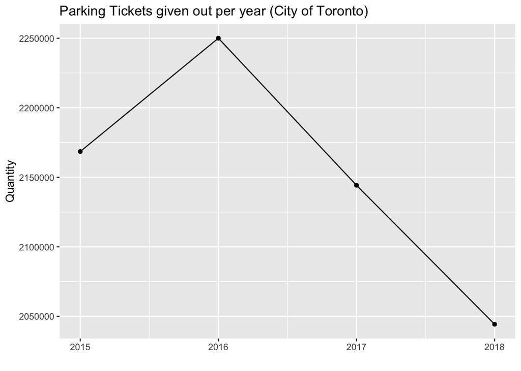

Between 2015-2018, The quantity of parking tickets giveb peaked in 2016 and slowly decreased thereafter.

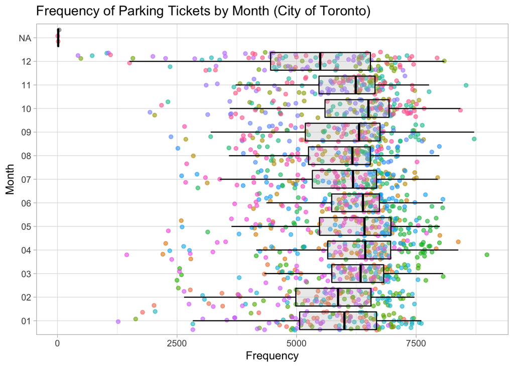

Parking tickets are handed out at the lowest frequency between December to February. Assuming that more parking violations are going unreported in the winter, a possible solution could be to get City of Toronto’s snow removal workers to flag cars’ license plates that are in violation of local parking laws. Often in the winter, cars are found to be blocking areas of the road that need to be cleared. A system like this where car owners are not just kept accountable by parking enforcers but also snow removal workers would result in clearer and safer roads.

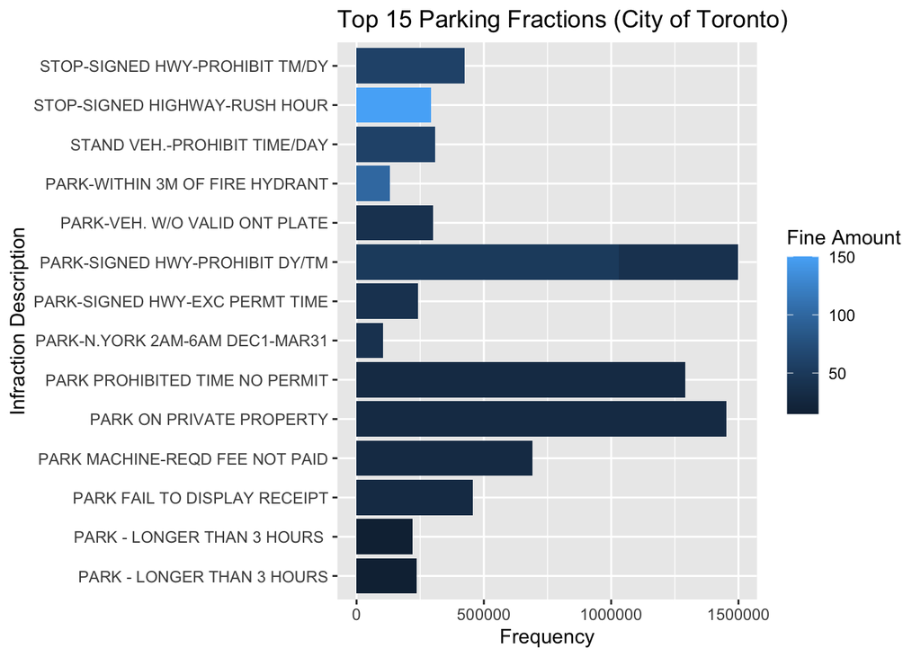

The top 3 parking violations given out all have to do with parking at the wrong time and/or place. A possible solution would be to create a parking app that tells users whether they are in violation of local parking by-laws based on the time and the user’s current location.